# Dot-Density Example

Jens von Bergmann

2017-08-04

First we install cancensus, grab the newest version just in case. Don’t forget to set your API key, refer to the [README file](https://github.com/mountainMath/cancensus) for instructions how to get your own.

```r
#library(devtools)
#devtools::install_github('mountainmath/cancensus')
library(cancensus)
# options(cancensus.api_key)='<your API key>'
```

Load data we want to use for dot density map, use the [CensusMapper API tool](https://censusmapper.ca/api) to select variabes and regions, and we add the `format='sp'` option to read the data in `sp` format.

```r
sp <- get_census(geo_format='sp',dataset='CA16', regions=list(CMA="59933"), vectors=c("v_CA16_2066","v_CA16_2060","v_CA16_1916","v_CA16_1727","v_CA16_1937","v_CA16_1958","v_CA16_1973"), level='DA')
```

```
Reading vectors data from local cache.
Reading geo data from local cache.
```

For plotting, we also want to plot the administrative boundaries as a base layer for better orientation.

```r
# load data for background polygons (geograhic data only)
base_geom <- get_census(geo_format ='sp', dataset='CA16', regions=list(CMA="59933"),  level='CSD')
```

```
Reading geo data from local cache.
```

Next we neet to prepare the data for mapping, we rename the variables and set the colours

```r
#categories to map and their colors
categories=c("Cantonese","Mandarin","Punjabi","Farsi","Tagalog","Korean","Spanish")
colors <- c("#ffff66", "#ff3300","#66ff33","#00ffff","#0066ff","#ff66ff","#6600cc")
# rename columns for better readability
for (i in 1:length(categories)) {x=categories[i]; colnames(sp@data)[grep(x,colnames(sp@data))]<-x}
```

To make the map we have defined a convenience function to handle the dot-density logic. Sparing the details, we need to supply, the data, categories (a vector with the fields we want to map), the colours for each field, a scale (how many people per dot on the map), the base geometry for reference, a map title and map attribution.

All that’s left is to call the plot function with our data.

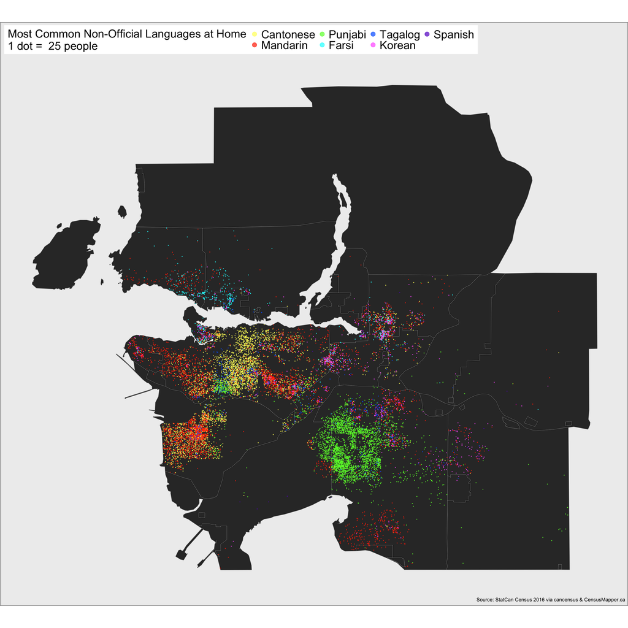

```r
dot_density(geo_data=sp,categories=categories,colors=colors,scale=25,base_geo_data=base_geom,'Most Common Non-Official Languages at Home',attribution="StatCan Census 2016")
```